# Water Potability

The Boop Beepers

Author

Malva de Boor, Albert Song, Henry Shavel, Tyler McLaughlin

Published

March 13, 2023

Abstract

*A logistic model was developed to determine how different chemical characteristics of water can affect the potability. Exploratory data analysis revealed that none of the possible predictors had correlation with the target variable. Therefore, models were developed by forward and backward stepwise regression with all of the possible variables and their 2-factor interaction terms. A Ridge regression was also performed on all possible predictors. The model obtained from backwards selection was determined to be the best model and all possible cubic transformations were tried on the model but none improved the model and were therefore determined to be statistically insignificant. We recommend that our stakeholder living in areas without safe drinking water to not use our model. The false positve rate is too high and could jeopardize their health. For environmental regulators and governmental water control institutions, we recommend that they look into researching the effects pH, solid concentration, and sulfate concentration has on water. For biotech research companies, we found that pH, solids concentration, and sulfate concetrations were the most relevant variables to determining water potability.*

## 1 Background / Motivation

Water is vital to the survival of all kinds of life. More relevantly, humans require a clean and safe, or in other words potable, water supply to drink in order to stay healthy. Drinking unpotable water can result in various health issues like gastrointestinal illness, reproductive problems, and neurological disorders [1]. Because the safety of water is so important for the health of the general population, efforts must be made to conserve the potability of water supplies via monitoring of the potability or locate potable water supplies for those that don’t have them via testing of the water potability. The quality of the water in any given water supply can be affected by various factors, including sedimentation, polluted runoff, and improperly maintained pipes [1]. These factors change different chemical characteristics of the water like its pH, the concentration of dissolved solids, or the concentration of chemicals like sulfates or trihalomethanes. Understanding how these different chemical characteristics play a role in the potability of a given water sample would allow for easier prediction of the potability of a given water sample, making it easier to manage water supplies and ensure water safety.

## 2 Problem statement

We are attempting to determine how different chemical characteristics of water can affect the potability (whether it is safe to drink or not).

The is both an inference and a prediction problem. It is both important to understand how chemical characteristics relate to water potability (inference) and be able to predict whether water will be safe to drink based on the chemical characteristics (prediction).

## 3 Data sources

We used an open-access dataset on water potability from Kaggle. https://www.kaggle.com/datasets/artimule/drinking-water-probability

The dataset contains information on several chemical characteristics of water samples and the classification of each water sample as potable or not. The included characteristics are: pH, Hardness, Solids, Chloramines, Sulfates, Conductivity, Organic carbon, Trihalomethanes, and Turbidity.

From Kaggle, the variables are defined as follows:

Potability: Indicates if water is safe to drink where 1 means safe to drink and 0 means not safe.

pH value: PH is an important parameter in evaluating the acid-base balance of water. It is also the indicator of the acidic or alkaline condition of water status. WHO has recommended the maximum permissible limit of pH from 6.5 to 8.5. The current investigation ranges were 6.52–6.83 which are in the range of WHO standards.

Hardness: Hardness is mainly caused by calcium and magnesium salts. These salts are dissolved from geologic deposits through which water travels. The length of time water is in contact with hardness-producing material helps determine how much hardness there is in raw water. Hardness was originally defined as the capacity of water to precipitate soap caused by Calcium and Magnesium.

Solids: Water has the ability to dissolve a wide range of inorganic and some organic minerals or salts such as potassium, calcium, sodium, bicarbonates, chlorides, magnesium, sulfates, etc. These minerals produced an unwanted taste and diluted color in the appearance of water. This is the important parameter for the use of water. The water with a high TDS value indicates that water is highly mineralized. The desirable limit for TDS is 500 mg/l and the maximum limit is 1000 mg/l which is prescribed for drinking purposes.

Chloramines: Chlorine and chloramine are the major disinfectants used in public water systems. Chloramines are most commonly formed when ammonia is added to chlorine to treat drinking water. Chlorine levels up to 4 milligrams per liter (mg/L or 4 parts per million (ppm)) are considered safe in drinking water.

Sulfate: Sulfates are naturally occurring substances that are found in minerals, soil, and rocks. They are present in ambient air, groundwater, plants, and food. The principal commercial use of sulfate is in the chemical industry. Sulfate concentration in seawater is about 2,700 milligrams per liter (mg/L). It ranges from 3 to 30 mg/L in most freshwater supplies, although much higher concentrations (1000 mg/L) are found in some geographic locations.

Conductivity: Pure water is not a good conductor of electric current rather’s a good insulator. An increase in ions concentration enhances the electrical conductivity of water. Generally, the amount of dissolved solids in water determines electrical conductivity. Electrical conductivity (EC) actually measures the ionic process of a solution that enables it to transmit current. According to WHO standards, EC value should not exceed 400 μS/cm.

Organic_carbon: Total Organic Carbon (TOC) in source waters comes from decaying natural organic matter (NOM) as well as synthetic sources. TOC is a measure of the total amount of carbon in organic compounds in pure water. According to US EPA < 2 mg/L as TOC in treated / drinking water, and < 4 mg/Lit in source water which is use for treatment.

Trihalomethanes: THMs are chemicals that may be found in water treated with chlorine. The concentration of THMs in drinking water varies according to the level of organic material in the water, the amount of chlorine required to treat the water, and the temperature of the water that is being treated. THM levels up to 80 ppm are considered safe in drinking water.

Turbidity: The turbidity of water depends on the quantity of solid matter present in the suspended state. It is a measure of the light-emitting properties of water and the test is used to indicate the quality of waste discharge with respect to the colloidal matter. The mean turbidity value obtained for Wondo Genet Campus (0.98 NTU) is lower than the WHO recommended value of 5.00 NTU.

## 4 Stakeholders

We are considering three main categories of stakeholders for this project. First, governmental and environmental regulatory organizations would be interested in the results of our project. They are responsible for providing and conserving potable water supplies for the general population. Because of their status as governmental organizations, it is a requirement of their job that they succeed in improving and preserving water potability or else risk the safety of many citizens. Understanding what characteristics of water most heavily influence water potability would be beneficial to them as it will let them know what qualities of the water and the environment of the water supply they should focus research and conservation efforts on in order to preserve the potability of the water.

Other stakeholders include biotechnology research companies that are developing tests for water potability. They would also benefit from understanding what qualities of water are most relevant to the potability of water as they would know what characteristics to base their tests on for the highest accuracy of the test. Similarly, if our model meets our standards for classification accuracy and FPR, it would suggest that our method of prediction based on chemical characteristics is highly successful. Tests for water potability would be able to draw directly from that prediction potential in order to classify water as potable or not. With a more accurate test thanks to our model, they may experience higher demand and may thus benefit financially.

In our list of stakeholders, we would also like to include include people who live in areas where water potability is an issue. Although they may not have the scientific equipment to directly predict whether a water source is potable, this project will benefit them as they can use our model to understand how certain characteristics of their environment that are affecting the water will change whether or not it is safe to drink. For example, if they can see that the water has lots of suspended solids and it can conduct electricity, those are two characteristics that may be included in the model and can be used to make an inference about the potability of their water. In the end, understanding how their water potability is affected by different chemicals can improve their safety and their health.

## 6 Exploratory data analysis

Relationships between explanatory variables and potability: - Through looking at boxplots of explanatory variables against potability, all the variables have minimal relationship with potability. There was very little difference between the boxplots when water was safe to drink versus not safe to drink, showing minimal, if any, relationship. The lack of relationships highlights that it might not be possible to get a highly performing model for water potability based on these chemical components or their transformations as predictors.

## 7 Approach

Because the target variable for this problem was a binary variable, we opted to use a logistic model to fit the data. The two metrics we tried to focus our efforts on were classification accuracy and false positive rate - we attempted to maximize classification accuracy and minimize the false positive rate (FPR). Classification accuracy is relevant in this case because the end goal for our model is to have it correctly predict whether or not water is potable based on the water’s chemical characteristics. Hence, a higher classification accuracy would imply that our model more correctly predicted the potability. At the same time, it was important to us to minimize the false positive rate given that it is the metric with the highest stakes in the particular problem. Since the potability of water is vital to human health and drinking unpotable water can have adverse side effects on someone’s health, it is much preferred that someone avoid drinking water that is potable (represented by the false negative rate) than drink water that is not potable (the false positive rate). In addition to these two metrics, when completing some of the variable selection methods as described later in this report, we used classification accuracy on test data as well as AIC and BIC of the model to choose the best variable subset. This is because AIC and BIC account for the number of predictors and prevent overfitting; this ended up being unnecessary as seen in our ridge regression results, but we wanted to be cautious nonetheless.

## 8 Developing the model

In order to determine what steps need to be taken, we started developing a model by first making a baseline model that used each continuous variable as a predictor with no interaction terms or polynomial transformations. The baseline model was very similar to the naive model since it predicted most values to be zero. In fact, only 3 out of 1609 entries of the test dataset were predicted to be potable. The baseline model only improved the classification accuracy by 0.1% from the Naive model and needed to improve. Based on the EDA, we predicted that we wouldn’t have any multicollinearity problems in our model since the correlations between the variables were all very low (correlation coefficients under 0.12). To confirm this prediction, we ran a ridge regression using all the predictors. In our ridge regression, the testing parameter was tested for alpha values from 0 to 1 with increments of 0.01. The best tuning parameter was determined to have an alpha value of 0 proving that there are no multicollinearity problems with our data and the best model was the one determined by the least squares regression.

Given that the model was not up to our standards of 95% accuracy and 1% FPR (as set before we started this project) and given the lack of conclusions we gathered from EDA, we concluded that our best chance to find the best model was to perform stepwise regression. We ran a forward stepwise regression with all possible variables and all their 2-factor interaction terms to determine the best model. We used classification accuracy, AIC, and BIC as the metrics to determine the best model. Forward stepwise selection determined that the model with 31 predictors was the best model based on accuracy, that with 40 predictors was the best based on AIC, and that with 16 predictors was the best based on BIC. The 31 predictor model had the maximum classification accuracy of 71.6% and a false positive rate of 8.4%. The 16 predictor model had a lower FPR of 6.8% but also a lower classification accuracy of 69.2%. Both of these models had a higher classification accuracy than the baseline model but also much higher false positive rates.

The final model equation is: Probability of Potability = 1/(1+e^-(-23.9065+2.8165*ph+0.0004*Solids-0.4270*Chloramines+0.0842*Sulfate-0.0138*Conductivity-0.0950*Organic_carbon-0.0022*(ph + Hardness)+0.1448*(ph + Chloramines)-0.0096*(ph + Sulfate)-0.0004*(ph + Conductivity)-2.95e-07*(Hardness + Solids)-0.0016*(Hardness + Chloramines)+5.571e-05*(Hardness + Sulfate)+3.777e-05*(Hardness + Conductivity)-1.209e-05*(Solids + Chloramines)-9.902e-07*(Solids + Sulfate)+4.434e-08*(Solids + Conductivity)-9.351e-07*(Solids + Organic_carbon)+4.074e-07*(Solids + Trihalomethanes)-0.0001*(Sulfate + Trihalomethanes)+0.0002*(Conductivity + Organic_carbon)+6.752e-05*(Conductivity + Trihalomethanes))).

## 9 Limitations of the model with regard to inference / prediction

Our model was meant to help both with inference and with prediction. For inference, our model is limited in that there are many of interaction terms, which makes it quite difficult to interpret how any one variable would affect the log-likelihood of the water being potable. Additionally, since our model had limited training data, we are limited to inferences based on the range of data we had. To be specific, our inferences are limited to water with a pH from 0.23 - 14.00, a hardness with range from 73.49 - 317.34, a total dissolved solids concentration that ranges from 320.94 - 56488.67 ppm, a chlorine concetration that ranges from 1.39 - 13.13 ppm, a sulfate concentration that ranges from 129.00 - 481.03 ppm, a conductivity that ranges from 201.62 - 753.34 μS/cm, a total organic carbon concetration that ranges from 2.20 - 27.01 ppm, a trihalomethane concentration that ranges from 8.58 - 124.00 ppm, and a turbidity value that ranges from 1.45 - 6.49 NTU.

For prediction, our model can be used immediatly to predict whether a water sample is potable or not as soon as the chemical tests are run, as there is not any time delay associated with the data that our model uses to predict water potability. However, our model only had an accuracy of 72.6%, which was only 12.9% better than our naive model which had a 59.7% accuracy. Therefore, our model is limited in how accurate is it, as we were hoping that it could have a 95% accuracy for prediction. Moreover, our false positive rate was 7.6%, which we thought was limiting as we desired a 1% false positive rate due to the serious nature of drinking unpotable water.

Our model should not become obsolete over time as water potability should not change over time in terms of its chemical composition, as a sample of water with the same chemical composition will be, for all intents and purposes, the same sample of water if it has the same chemical composition even sometime far in the future.

## 10 Conclusions and Recommendations to stakeholder(s)

From our model, we can draw several inference conclusions. For instance, we can conclude that having a higher pH, solids concentration, and sulfate concentration correlates with a higher likelihood of a water sample being potable, all with a statistical significance. We also found that higher chloramine concentration, organic carbon concentration, and conductivity all correlated with a lower likelihood of a water potability. However, these three were all less stastically significant than the pH, solids concentration and sulfate concentration. We also found that our interaction terms with the highest statisticaly significance were the ones that interacted with pH levels, meaning that we are most confident that our pH levels interacted with the other variables in the training data set.

On the prediction side of things, we found that our model had an accuracy of 72.6%, and a false positive rate of 7.6%, This is compared to our naive model which had an accuracy of 59.7%. Our final model was not that much better than the naive model in terms of accuracy, and obviously worse in terms of false positive rate.

For our stakeholders living in areas without safe drinking water, we would not recommend using our model to predict water potability with the purpose of drinking the water, as our false positive rate is too high for our standards for us to consider the model safe to use to determine water potability. In addition, our accuracy is lower than we would like it to be, so we feel that more data is needed for stakeholders interested in using our model to predict potability.

For environmental regulators and governmental water control institutions, we recommend that they look into researching the effects pH, solid concentration, and sulfate concentration has on water, as they all appeared to increase the likelihood of water potability when they increased with a high statistical significance. They should also research more into the interactions that pH has with other concentrations such as chloramines, and sulfates as those interactions had high statistical significances.

For biotech research companies, we found that pH, solids concentration, and sulfate concetrations were the most relevant variables to determining water potability. Therefore, we recommend that these companies focus on these variables when developing tests for water potability.

As mentioned in our limitations section, we advise our stakeholders to be aware of several limitations in our model. Again, our accuracy is quite low, especially when compared to the naive model, and our false positive rate is alarmingly high. While our model is not a one-time-use, and can be used for the future, we recommend that more data be gathered, with perhaps more dependent variables being tested for, so that further improvements can be made for our model so that we can recommend using it to predict water potability.

## GitHub and individual contribution

The link to our github is: https://github.com/meepdeboor/Data-Science-2-Group-Project.git

## Individual contribution

[output not shown]

### 10.1 Challenges with GitHub

- We struggled to figure out how to work concurrently on GitHub. There were a few instances where we had work that was lost because of conflicts when pushing updates and not being able to see what the changes were and approving or denying the changes. This could be in part attributed to the annoyances of using GitHub with jupyter notebook files as opposed to python files.
- We don’t feel super comfortable with GitHub since we felt that we had to be very cautious when working on the reports as to not destroy or lose any work while another person was working.
- Given that last quarter we worked in the same room, working on the same document and transfering code back and forth via Discord, GitHub felt much more clunky and was disruptive to our work flow.

## References

[1] Importance of Water Quality and Testing | Public Water Systems | Drinking Water | Healthy Water | CDC. https://www.cdc.gov/healthywater/drinking/public/water_quality.html (accessed 2023-03-12).

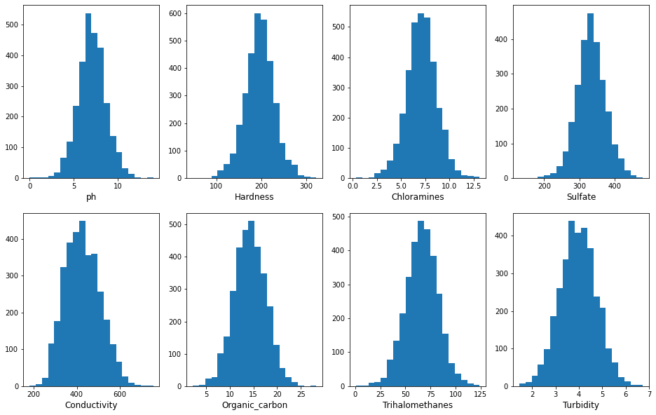

## 12 Distribution of Target Variable

[output not shown]

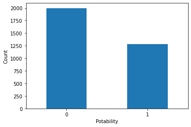

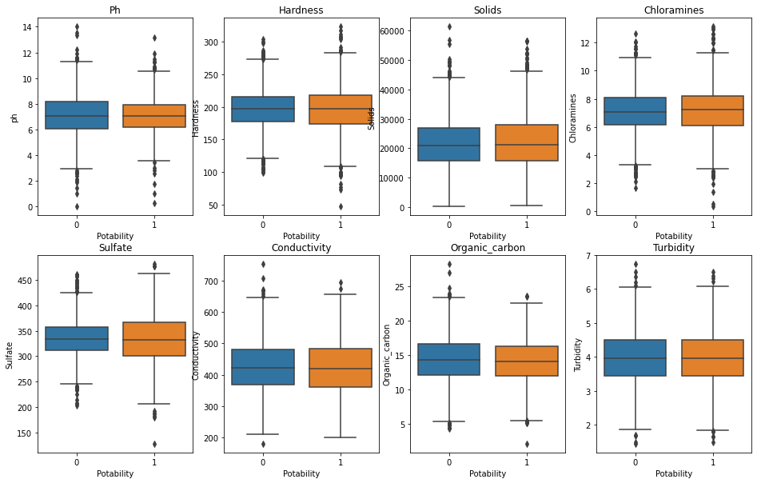